# Objective: Implementing a regression model to analyze Boston housing price with 13 features using Amazon SageMaker.

## Approches

1. set up environment(AWS)
2. data exploration
3. data preprocessing
4. data visualization
5. model training using S3 and SageMaker
6. Model evaluation

```python
import numpy as np
import pandas as pd
import matplotlib.pyplot as plt
import seaborn as sns
import sagemaker
from sagemaker.xgboost.estimator import XGBoost
from sklearn.datasets import fetch_openml
from sklearn.preprocessing import StandardScaler
from sklearn.model_selection import train_test_split
from sagemaker.amazon.linear_learner import LinearLearner
from sklearn.metrics import mean_squared_error, r2_score
import boto3
import os
import logging


# Configure logging
logging.basicConfig(level=logging.INFO)
logging.getLogger('matplotlib').setLevel(logging.ERROR)

logger = logging.getLogger(__name__)

# Set plotting style
sns.set(style="whitegrid")
plt.rcParams['figure.figsize'] = (12, 8)
```

### Load the data

```python
from sklearn.datasets import fetch_openml

boston = fetch_openml(name="boston", version=1, as_frame=True)
df_X, df_y = boston.data, boston.target
df_boston = pd.concat([df_X, df_y], axis = 1)
df_boston
```

|  | CRIM | ZN | INDUS | CHAS | NOX | RM | AGE | DIS | RAD | TAX | PTRATIO | B | LSTAT | MEDV |
| --- | --- | --- | --- | --- | --- | --- | --- | --- | --- | --- | --- | --- | --- | --- |
| 0 | 0.00632 | 18.0 | 2.31 | 0 | 0.538 | 6.575 | 65.2 | 4.0900 | 1 | 296.0 | 15.3 | 396.90 | 4.98 | 24.0 |
| 1 | 0.02731 | 0.0 | 7.07 | 0 | 0.469 | 6.421 | 78.9 | 4.9671 | 2 | 242.0 | 17.8 | 396.90 | 9.14 | 21.6 |
| 2 | 0.02729 | 0.0 | 7.07 | 0 | 0.469 | 7.185 | 61.1 | 4.9671 | 2 | 242.0 | 17.8 | 392.83 | 4.03 | 34.7 |
| 3 | 0.03237 | 0.0 | 2.18 | 0 | 0.458 | 6.998 | 45.8 | 6.0622 | 3 | 222.0 | 18.7 | 394.63 | 2.94 | 33.4 |
| 4 | 0.06905 | 0.0 | 2.18 | 0 | 0.458 | 7.147 | 54.2 | 6.0622 | 3 | 222.0 | 18.7 | 396.90 | 5.33 | 36.2 |
| ... | ... | ... | ... | ... | ... | ... | ... | ... | ... | ... | ... | ... | ... | ... |
| 501 | 0.06263 | 0.0 | 11.93 | 0 | 0.573 | 6.593 | 69.1 | 2.4786 | 1 | 273.0 | 21.0 | 391.99 | 9.67 | 22.4 |
| 502 | 0.04527 | 0.0 | 11.93 | 0 | 0.573 | 6.120 | 76.7 | 2.2875 | 1 | 273.0 | 21.0 | 396.90 | 9.08 | 20.6 |
| 503 | 0.06076 | 0.0 | 11.93 | 0 | 0.573 | 6.976 | 91.0 | 2.1675 | 1 | 273.0 | 21.0 | 396.90 | 5.64 | 23.9 |
| 504 | 0.10959 | 0.0 | 11.93 | 0 | 0.573 | 6.794 | 89.3 | 2.3889 | 1 | 273.0 | 21.0 | 393.45 | 6.48 | 22.0 |
| 505 | 0.04741 | 0.0 | 11.93 | 0 | 0.573 | 6.030 | 80.8 | 2.5050 | 1 | 273.0 | 21.0 | 396.90 | 7.88 | 11.9 |

506 rows × 14 columns

#### -Variables

There are 14 attributes in each case of the dataset. They are:

CRIM - per capita crime rate by town  
ZN - proportion of residential land zoned for lots over 25,000 sq.ft.  
INDUS - proportion of non-retail business acres per town.  
CHAS - Charles River dummy variable (1 if tract bounds river; 0 otherwise)  
NOX - nitric oxides concentration (parts per 10 million)  
RM - average number of rooms per dwelling  
AGE - proportion of owner-occupied units built prior to 1940  
DIS - weighted distances to five Boston employment centres  
RAD - index of accessibility to radial highways  
TAX - full-value property-tax rate per 10,000 dollors  
PTRATIO - pupil-teacher ratio by town  
B - 1000(Bk - 0.63)^2 where Bk is the proportion of blacks by town  
LSTAT - % lower status of the population  
MEDV - Median value of owner-occupied homes in $1000's

### basic exploratory data analysis (EDA)

```python
# Display basic information about the dataset
print("Dataset shape:", df_boston.shape)
print("\nFeature descriptions:")
for i, feature in enumerate(boston.feature_names):
    print(f"{feature}: {boston.feature_names[i]}")

print("\nTarget description:")
print(f"MedHouseVal: {boston.target_names[0]}")

# Display the first few rows of the dataset
print("\nFirst 5 rows of the dataset:")
df_boston.head()
```

```
Dataset shape: (506, 14)

Feature descriptions:
CRIM: CRIM
ZN: ZN
INDUS: INDUS
CHAS: CHAS
NOX: NOX
RM: RM
AGE: AGE
DIS: DIS
RAD: RAD
TAX: TAX
PTRATIO: PTRATIO
B: B
LSTAT: LSTAT

Target description:
MedHouseVal: MEDV

First 5 rows of the dataset:
```

|  | CRIM | ZN | INDUS | CHAS | NOX | RM | AGE | DIS | RAD | TAX | PTRATIO | B | LSTAT | MEDV |
| --- | --- | --- | --- | --- | --- | --- | --- | --- | --- | --- | --- | --- | --- | --- |
| 0 | 0.00632 | 18.0 | 2.31 | 0 | 0.538 | 6.575 | 65.2 | 4.0900 | 1 | 296.0 | 15.3 | 396.90 | 4.98 | 24.0 |
| 1 | 0.02731 | 0.0 | 7.07 | 0 | 0.469 | 6.421 | 78.9 | 4.9671 | 2 | 242.0 | 17.8 | 396.90 | 9.14 | 21.6 |
| 2 | 0.02729 | 0.0 | 7.07 | 0 | 0.469 | 7.185 | 61.1 | 4.9671 | 2 | 242.0 | 17.8 | 392.83 | 4.03 | 34.7 |
| 3 | 0.03237 | 0.0 | 2.18 | 0 | 0.458 | 6.998 | 45.8 | 6.0622 | 3 | 222.0 | 18.7 | 394.63 | 2.94 | 33.4 |
| 4 | 0.06905 | 0.0 | 2.18 | 0 | 0.458 | 7.147 | 54.2 | 6.0622 | 3 | 222.0 | 18.7 | 396.90 | 5.33 | 36.2 |

```python
# Explore the dataset statistics
print("Dataset statistics:")
df_boston.describe()
```

```
Dataset statistics:
```

|  | CRIM | ZN | INDUS | NOX | RM | AGE | DIS | TAX | PTRATIO | B | LSTAT | MEDV |
| --- | --- | --- | --- | --- | --- | --- | --- | --- | --- | --- | --- | --- |
| count | 506.000000 | 506.000000 | 506.000000 | 506.000000 | 506.000000 | 506.000000 | 506.000000 | 506.000000 | 506.000000 | 506.000000 | 506.000000 | 506.000000 |
| mean | 3.613524 | 11.363636 | 11.136779 | 0.554695 | 6.284634 | 68.574901 | 3.795043 | 408.237154 | 18.455534 | 356.674032 | 12.653063 | 22.532806 |
| std | 8.601545 | 23.322453 | 6.860353 | 0.115878 | 0.702617 | 28.148861 | 2.105710 | 168.537116 | 2.164946 | 91.294864 | 7.141062 | 9.197104 |
| min | 0.006320 | 0.000000 | 0.460000 | 0.385000 | 3.561000 | 2.900000 | 1.129600 | 187.000000 | 12.600000 | 0.320000 | 1.730000 | 5.000000 |
| 25% | 0.082045 | 0.000000 | 5.190000 | 0.449000 | 5.885500 | 45.025000 | 2.100175 | 279.000000 | 17.400000 | 375.377500 | 6.950000 | 17.025000 |
| 50% | 0.256510 | 0.000000 | 9.690000 | 0.538000 | 6.208500 | 77.500000 | 3.207450 | 330.000000 | 19.050000 | 391.440000 | 11.360000 | 21.200000 |
| 75% | 3.677083 | 12.500000 | 18.100000 | 0.624000 | 6.623500 | 94.075000 | 5.188425 | 666.000000 | 20.200000 | 396.225000 | 16.955000 | 25.000000 |
| max | 88.976200 | 100.000000 | 27.740000 | 0.871000 | 8.780000 | 100.000000 | 12.126500 | 711.000000 | 22.000000 | 396.900000 | 37.970000 | 50.000000 |

We can know the standard deviation of ZN, AGE, TAX, and B is higher than other features, so we need further exploration of this data to see whether there're outliers or not. Outliers might influence the result.

```python
# Check for missing values
missing_values = df_boston.isnull().sum()
print("Missing values per column:")
print(missing_values)

# If there are no missing values, print a confirmation
if missing_values.sum() == 0:
    print("\nGreat! The dataset has no missing values.")
```

```
Missing values per column:
CRIM       0
ZN         0
INDUS      0
CHAS       0
NOX        0
RM         0
AGE        0
DIS        0
RAD        0
TAX        0
PTRATIO    0
B          0
LSTAT      0
MEDV       0
dtype: int64

Great! The dataset has no missing values.
```

Therefore, we have no need to deal with missing values.

### EDA - visuallization

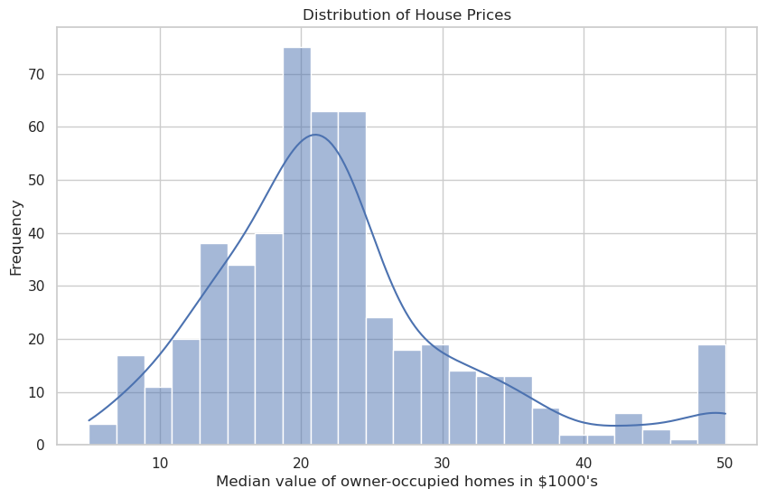

```python
# Visualize the distribution of the target variable
plt.figure(figsize=(10, 6))
sns.histplot(df_y, kde=True)
plt.title('Distribution of House Prices')
plt.xlabel("Median value of owner-occupied homes in $1000's")
plt.ylabel('Frequency')
plt.show()
```

As we can see from aboved picture, the most common median value of owner-occupied homes is 20(in $1000's).

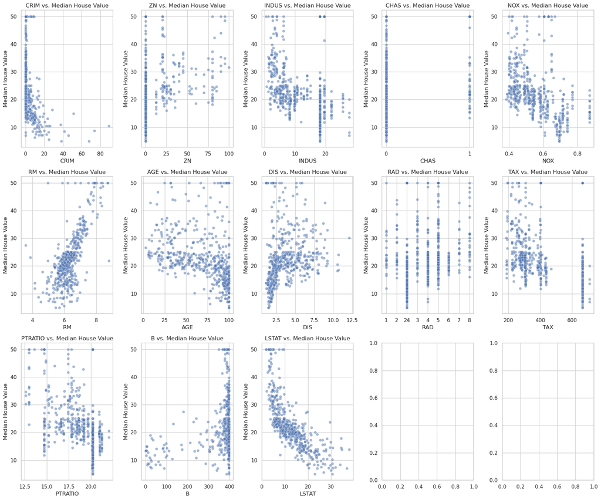

```python
# Visualize relationships between key features and the target
fig, axes = plt.subplots(3, 5, figsize=(18, 15))
axes = axes.flatten()

# Plot scatter plots for each feature against the target
for i, feature in enumerate(boston.feature_names):
    if i < len(axes):
        sns.scatterplot(x=df_X[feature], y=df_y, alpha=0.5, ax=axes[i])
        axes[i].set_title(f'{feature} vs. Median House Value')
        axes[i].set_xlabel(feature)
        axes[i].set_ylabel('Median House Value')

plt.tight_layout()
plt.show()
```

Critical Thinking Question: Based on your exploration, which feature do you think might be most strongly related to house prices? Why?

Critical Thinking Answer: RM is likely most correlated with price, because through the aboved picture, I find the picture with RM vs. Median House Value title is high posotive correlated.

```python
print("CHAS:", df_X['CHAS'].value_counts())
print("RAD:", df_X['RAD'].value_counts())
```

```
CHAS: 0    471
1     35
Name: CHAS, dtype: int64
RAD: 24    132
5     115
4     110
3      38
6      26
8      24
2      24
1      20
7      17
Name: RAD, dtype: int64
```

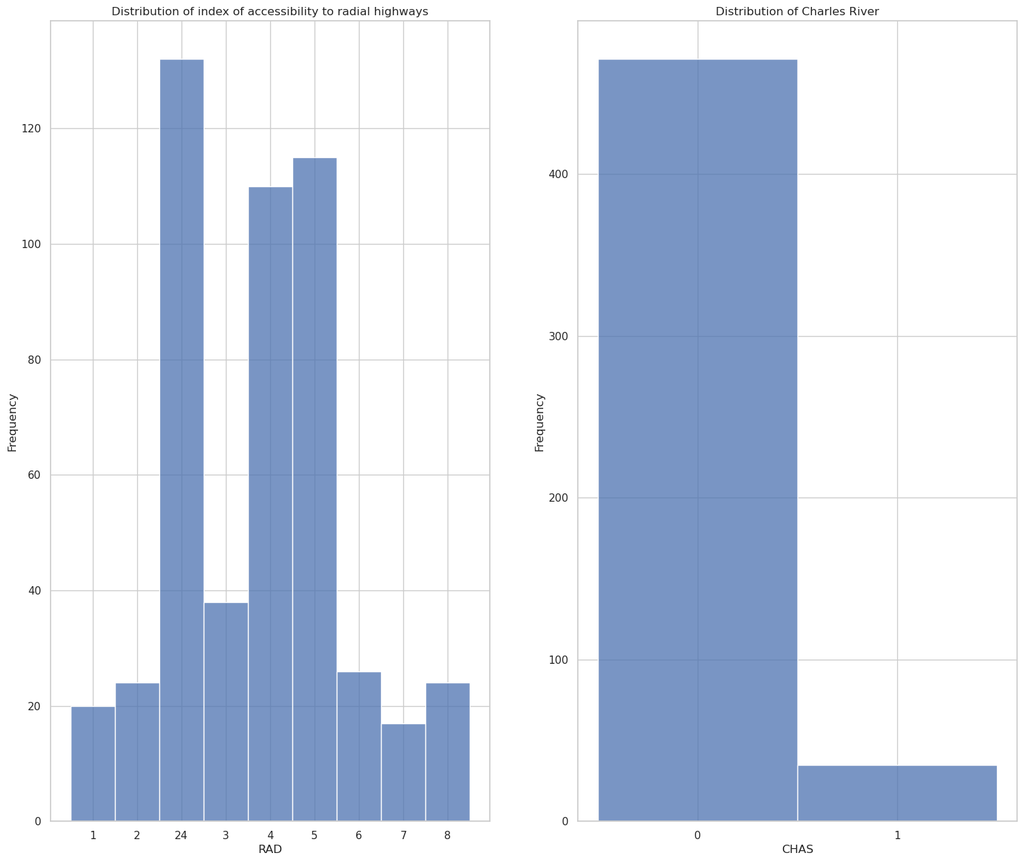

```python
# See category distribution
fig, axes = plt.subplots(1, 2, figsize=(18, 15))

sns.histplot(df_X["RAD"], discrete=True, ax=axes[0])
axes[0].set_title("Distribution of index of accessibility to radial highways")
axes[0].set_xlabel("RAD")
axes[0].set_ylabel('Frequency')

axes = axes.flatten()
sns.histplot(df_X["CHAS"], discrete=True, ax=axes[1])
axes[1].set_title("Distribution of Charles River")
axes[1].set_xlabel("CHAS")
axes[1].set_ylabel('Frequency')

plt.show()
```

I find a lot of houses with index of accessibility to radial highways = 24, 4, or 5.  
I find houses which tract bounds river is just a few(CHAS=1).

### Data Preprocessing

```python
X = df_boston.drop('MEDV', axis=1)
y = df_boston['MEDV']
# Split the data into training and testing sets
X_train, X_test, y_train, y_test = train_test_split(X, y, test_size=0.2, random_state=42)
y_train = y_train.reset_index(drop=True)
y_test = y_test.reset_index(drop=True)

scaler = StandardScaler()
X_train_scaled = scaler.fit_transform(X_train)
X_test_scaled = scaler.transform(X_test)
X_train_scaled_df = pd.DataFrame(X_train_scaled, columns=X_train.columns)
X_test_scaled_df = pd.DataFrame(X_test_scaled, columns=X_test.columns)

train_df = X_train_scaled_df.copy()
train_df['MEDV'] = y_train
test_df = X_test_scaled_df.copy()
test_df['MEDV'] = y_test

print(f"Training set shape: {train_df.shape}")
print(f"Testing set shape: {test_df.shape}")

cols = train_df.columns.tolist()
cols.remove('MEDV')
cols = ['MEDV'] + cols

train_df = train_df[cols]
test_df = test_df[cols]
```

```
Training set shape: (404, 14)
Testing set shape: (102, 14)
```

```python
# Save the processed data to CSV files
train_df.to_csv('train_xgb.csv', index=False, header=False)
test_df.to_csv('test_xgb.csv', index=False, header=False)
print("Data reformatted for XGBoost and saved to CSV files.")
```

```
Data reformatted for XGBoost and saved to CSV files.
```

```python
# Initialize SageMaker session
sagemaker_session = sagemaker.Session()
role = sagemaker.get_execution_role()
bucket = sagemaker_session.default_bucket()
prefix = 'Boston-housing'

# Upload data to S3
train_s3_path = sagemaker_session.upload_data(
    path='train_xgb.csv',
    bucket=bucket,
    key_prefix=f'{prefix}/train'
)

test_s3_path = sagemaker_session.upload_data(
    path='test_xgb.csv',
    bucket=bucket,
    key_prefix=f'{prefix}/test'
)

print(f"Training data uploaded to: {train_s3_path}")
print(f"Testing data uploaded to: {test_s3_path}")
```

```
[03/10/25 07:33:56] INFO     Found credentials from IAM Role:                                   credentials.py:1132
                             BaseNotebookInstanceEc2InstanceRole
```

```
                    INFO     Found credentials from IAM Role:                                   credentials.py:1132
                             BaseNotebookInstanceEc2InstanceRole
```

```
Training data uploaded to: s3://sagemaker-us-east-1-181786711311/Boston-housing/train/train_xgb.csv
Testing data uploaded to: s3://sagemaker-us-east-1-181786711311/Boston-housing/test/test_xgb.csv
```

Critical Thinking Question: Why is scaling features important for many machine learning algorithms? How might unscaled features affect model performance?

Critical Thinking Answer: Scaling is important to ensure numerical stability and faster convergence.

### Model Training with SageMaker

```python
# Configure the XGBoost estimator
xgb = XGBoost(
    entry_point='script.py',
    framework_version='1.5-1',
    hyperparameters={
        'objective': 'reg:squarederror',
        'max_depth': 6,
        'eta': 0.1,
        'gamma': 5,
        'min_child_weight': 10,
        'subsample': 0.8,
        'colsample_bytree': 0.8,
        'verbosity': 1,
        'num_round': 100
    },
    role=role,
    instance_count=1,
    instance_type='ml.m5.xlarge',
    output_path=f's3://{bucket}/{prefix}/output'
)

# Create a training script
with open('script.py', 'w') as f:
    f.write("""
import argparse
import os
import json
import pandas as pd
import numpy as np
import xgboost as xgb
from sklearn.metrics import mean_squared_error

def model_fn(model_dir):
    model = xgb.Booster()
    model.load_model(os.path.join(model_dir, 'xgboost-model'))
    return model

if __name__ == '__main__':
    parser = argparse.ArgumentParser()

    # Hyperparameters
    parser.add_argument('--objective', type=str, default='reg:squarederror')
    parser.add_argument('--max_depth', type=int, default=5)
    parser.add_argument('--eta', type=float, default=0.2)
    parser.add_argument('--gamma', type=float, default=4)
    parser.add_argument('--min_child_weight', type=int, default=6)
    parser.add_argument('--subsample', type=float, default=0.8)
    parser.add_argument('--verbosity', type=int, default=1)
    parser.add_argument('--num_round', type=int, default=50)

    # SageMaker parameters
    parser.add_argument('--model_dir', type=str, default=os.environ.get('SM_MODEL_DIR'))
    parser.add_argument('--train', type=str, default=os.environ.get('SM_CHANNEL_TRAIN'))
    parser.add_argument('--validation', type=str, default=os.environ.get('SM_CHANNEL_VALIDATION'))

    args, _ = parser.parse_known_args()

    # Load data
    train_data = pd.read_csv(os.path.join(args.train, 'train_xgb.csv'), header=None)
    validation_data = pd.read_csv(os.path.join(args.validation, 'test_xgb.csv'), header=None)

    # Split into features and target
    X_train = train_data.iloc[:, 1:].values
    y_train = train_data.iloc[:, 0].values
    X_validation = validation_data.iloc[:, 1:].values
    y_validation = validation_data.iloc[:, 0].values

    # Create DMatrix
    dtrain = xgb.DMatrix(X_train, label=y_train)
    dvalidation = xgb.DMatrix(X_validation, label=y_validation)

    # Train model
    params = {
        'objective': args.objective,
        'max_depth': args.max_depth,
        'eta': args.eta,
        'gamma': args.gamma,
        'min_child_weight': args.min_child_weight,
        'subsample': args.subsample,
        'verbosity': args.verbosity
    }

    watchlist = [(dtrain, 'train'), (dvalidation, 'validation')]

    model = xgb.train(
        params=params,
        dtrain=dtrain,
        num_boost_round=args.num_round,
        evals=watchlist
    )

    # Evaluate model
    predictions = model.predict(dvalidation)
    rmse = np.sqrt(mean_squared_error(y_validation, predictions))
    print(f'Validation RMSE: {rmse:.4f}')

    # Save model
    model.save_model(os.path.join(args.model_dir, 'xgboost-model'))

    # Save feature importance
    feature_importance = model.get_score(importance_type='weight')
    with open(os.path.join(args.model_dir, 'feature_importance.json'), 'w') as f:
        json.dump(feature_importance, f)
""")

print("Training script created.")
```

```
[03/10/25 07:33:58] INFO     Found credentials from IAM Role:                                   credentials.py:1132
                             BaseNotebookInstanceEc2InstanceRole
```

```
                    INFO     Found credentials from IAM Role:                                   credentials.py:1132
                             BaseNotebookInstanceEc2InstanceRole
```

```
                    INFO     Ignoring unnecessary Python version: py3.                            image_uris.py:603
```

```
[03/10/25 07:33:59] INFO     Ignoring unnecessary instance type: ml.m5.xlarge.                    image_uris.py:530
```

```
Training script created.
```

```python
xgb.fit({
    'train': train_s3_path,
    'validation': test_s3_path
})

print("Model training completed!")
```

[output not shown]

```
                    INFO     Creating training-job with name:                                       session.py:1042
                             sagemaker-xgboost-2025-03-10-07-33-59-093
```

[output not shown]

[output cut: 182 more lines]

```
[91]#011train-rmse:1.41283#011validation-rmse:3.10843
[92]#011train-rmse:1.39466#011validation-rmse:3.11284
[93]#011train-rmse:1.38788#011validation-rmse:3.10957
[94]#011train-rmse:1.38112#011validation-rmse:3.10785
[95]#011train-rmse:1.37228#011validation-rmse:3.10469
[96]#011train-rmse:1.36411#011validation-rmse:3.10454
[97]#011train-rmse:1.35753#011validation-rmse:3.10023
[98]#011train-rmse:1.35260#011validation-rmse:3.10010
[99]#011train-rmse:1.34560#011validation-rmse:3.10257
Validation RMSE: 3.1026

2025-03-10 07:36:17 Completed - Training job completed
Training seconds: 99
Billable seconds: 99
Model training completed!
```

Critical Thinking Question: What are the advantages of training a model in the cloud (like SageMaker) compared to training locally on your computer?

Critical Thinking Answer: Cloud training allows scalability, avoids local hardware limitations, and simplifies deployment. In fact, you can also link to S3 to ensure data reliability.

```python
model_data = xgb.model_data  # getting SageMaker XGBoost Estimator from S3 model path

model_path = model_data.replace('s3://', '')
bucket_name = model_path.split('/')[0]
key = '/'.join(model_path.split('/')[1:])

s3 = boto3.client('s3')
s3.download_file(bucket_name, key, 'model.tar.gz')

# Extract the model artifacts
import tarfile
with tarfile.open('model.tar.gz') as tar:
    tar.extractall(path='model')

# Load the model locally
!pip install xgboost
import xgboost as xgb
model = xgb.Booster()
model.load_model('/home/ec2-user/SageMaker/model/xgboost-model')

# Make predictions locally
dtest = xgb.DMatrix(X_test.values)
predictions = model.predict(dtest)

# Evaluate the model
mse = mean_squared_error(y_test, predictions)
rmse = np.sqrt(mse)
r2 = r2_score(y_test, predictions)

print(f"Mean Squared Error: {mse:.4f}")
print(f"Root Mean Squared Error: {rmse:.4f}")
print(f"R² Score: {r2:.4f}")
```

```
Mean Squared Error: 97.9597
Root Mean Squared Error: 9.8975
R² Score: -0.3358
```

Critical Thinking Question: Based on your evaluation metrics, how well did your model perform? What might explain any discrepancies between predicted and actual values?  
The following are both Thoughtful analysis of model performance and response to critical thinking question

The result of this model is terrible.

1. Mean Squared Error (MSE): 97.96. and Root Mean Squared Error (RMSE): 9.90. High MSE and RMSE suggests large errors in predictions.
2. R² Score: -0.3358. R² is negative, indicating that the model performs worse than a simple mean predictor

Discrepancies between predicted and actual values may because:

1. The dataset may contain outliers or an uneven distribution of values, which could distort predictions.
2. XGBoost 'reg:squarederror' works well with linear data, but if the relationship between features and house prices is highly non-linear, additional feature engineering or preprocessing might be needed.
3. I did a bad job on tuning the model.

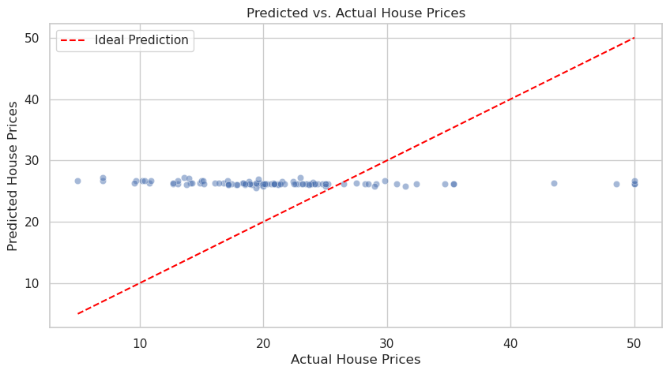

```python
# Scatter plot: Predicted vs. Actual House Prices
plt.figure(figsize=(10, 5))
sns.scatterplot(x=y_test, y=predictions, alpha=0.5)

# Plot a reference line (ideal prediction)
min_val = min(y_test.min(), predictions.min())
max_val = max(y_test.max(), predictions.max())
plt.plot([min_val, max_val], [min_val, max_val], color='red', linestyle='--', label='Ideal Prediction')

# Labels and title
plt.xlabel("Actual House Prices")
plt.ylabel("Predicted House Prices")
plt.title("Predicted vs. Actual House Prices")
plt.legend()
plt.show()
```